# Chapter 8 - R Exercises

```r
library(tidyverse)
library(bayesrules)
library(bayesplot)
library(rstan)
library(grid)
library(gridExtra)
library(janitor)
library(broom.mixed)
```

[output not shown]

## Exercise 8.6

### a)

```r
qbeta( c(0.025, 0.975), 4, 5 )
```

1. 0.157012770487058

2. 0.755136783633448

### b)

```r
qbeta( c(0.2, 0.8), 4, 5 )
```

1. 0.303225844664082

2. 0.583655355141237

### c)

```r
qgamma( c(0.025, 0.975), 1, 8 )
```

1. 0.00316472599803623

2. 0.461109931764242

## Exercise 8.7

### a)

```r
qgamma( c(0.005, 0.995), 1, 5 )
```

1. 0.00100250836470886

2. 1.05966347330961

### b)

```r
qnorm( c(0.025, 0.975), mean = 10, sd = 2 )
```

1. 6.08007203091989

2. 13.9199279690801

### c)

```r
qnorm( c(0.1, 0.9), mean = -3, sd = 1 )
```

1. -4.2815515655446

2. -1.7184484344554

## Exercise 8.8

### a)

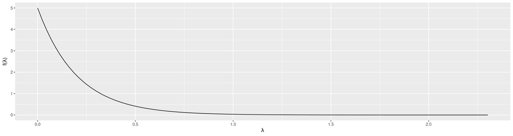

```r
options(repr.plot.width=15, repr.plot.height=4)
plot_gamma(1, 5)
```

```r
qgamma( c(0, 0.95), 1, 5 )
```

1. 0

2. 0.599146454710798

### b)

```r
qgamma( c(0.025, 0.975), 1, 5 )
```

1. 0.00506356159685798

2. 0.737775890822787

### d) and e)

```r
qnorm( c(0.025, 0.975), mean = -13, sd = 2 )
```

1. -16.9199279690801

2. -9.08007203091989

## Exercise 8.9

### a)

```r
post_pHa <- 1-pbeta(0.4, 4, 3)
post_pHa
```

0.8208

### b)

```r
post_pH0 <- pbeta(0.4, 4, 3)
post_pH0
```

0.1792

```r
postodds <- post_pHa / post_pH0
postodds
```

4.58035714285714

### c)

```r
prior_pHa <- 1-pbeta(0.4, 1, 0.8)
prior_pHa
```

0.664539805948974

```r
prior_pH0 <- pbeta(0.4, 1, 0.8)
prior_pH0
```

0.335460194051026

```r
priorodds <- prior_pHa / prior_pH0
priorodds
```

1.98097961467194

### d)

```r
postodds / priorodds
```

2.31216773203175

## Exercise 8.10

### a)

```r
post_pHa <- pnorm(5.2, mean=5, sd=3)
post_pHa
```

0.526576464300365

### b)

```r
post_pH0 <- 1-post_pHa
post_pH0
```

0.473423535699635

```r
postodds <- post_pHa / post_pH0
postodds
```

1.11227352379552

### c)

```r
prior_pHa <- pnorm(5.2, mean=10, sd=10)
prior_pHa
```

0.315613696516223

```r
prior_pH0 <- 1-prior_pHa
prior_pH0
```

0.684386303483777

```r
priorodds <- prior_pHa / prior_pH0
priorodds
```

0.461163081303108

### d)

```r
postodds / priorodds
```

2.4118876139273

## Exercise 8.11

### e)

```r
post_pred_pmf <- function(yprime) {
    choose(4, yprime) * gamma(110)/(gamma(18)*gamma(92)) * (gamma(18+yprime)*gamma(96-yprime))/gamma(114)
}
```

```r
post_pred_pmf_eval <- data.frame(yprime=c(0,1,2,3,4)) %>%
                        mutate(p=post_pred_pmf(yprime))
post_pred_pmf_eval
```

A data.frame: 5 × 2

| yprime <dbl> | p <dbl> |
| --- | --- |
| 0 | 0.4944360232 |
| 1 | 0.3747304597 |
| 2 | 0.1136150862 |
| 3 | 0.0162889012 |
| 4 | 0.0009295297 |

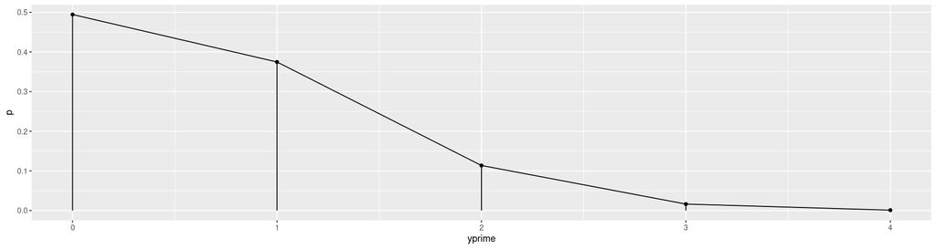

```r
ggplot( post_pred_pmf_eval, aes(x=yprime, y=p) ) +
    geom_point() +
    geom_line() +
    geom_segment( aes(x=yprime, xend=yprime, y=0, yend=p ) )
```

Expectation:

```r
sum( post_pred_pmf_eval$yprime * post_pred_pmf_eval$p )
```

0.654545454545425

## Exercise 8.12

### e)

```r
post_pred_pmf <- function(yprime) {
    1/factorial(yprime) * gamma(57+yprime)/(gamma(57)) * 51^57 / 52^(57+yprime)
}
```

```r
post_pred_pmf_eval <- data.frame(yprime=seq(0,10,1)) %>%
                        mutate(p=post_pred_pmf(yprime))
head( post_pred_pmf_eval, 10 )
```

A data.frame: 10 × 2

|  | yprime <dbl> | p <dbl> |
| --- | --- | --- |
| 1 | 0 | 3.306050e-01 |
| 2 | 1 | 3.623940e-01 |
| 3 | 2 | 2.021043e-01 |
| 4 | 3 | 7.643689e-02 |
| 5 | 4 | 2.204910e-02 |
| 6 | 5 | 5.173059e-03 |
| 7 | 6 | 1.027980e-03 |
| 8 | 7 | 1.779196e-04 |
| 9 | 8 | 2.737224e-05 |
| 10 | 9 | 3.801700e-06 |

```r
sum( post_pred_pmf_eval$p )
```

0.99999993662633

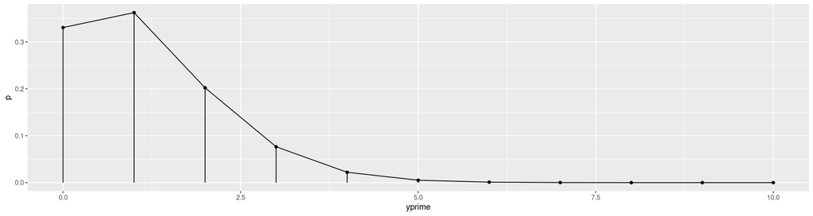

```r
ggplot( post_pred_pmf_eval, aes(x=yprime, y=p) ) +
    geom_point() +
    geom_line() +
    geom_segment( aes(x=yprime, xend=yprime, y=0, yend=p ) )
```

## Exercise 8.13

### e)

```r
post_pred_pdf <- function(yprime) {
    dnorm(yprime, mean=-1, sd=sqrt(9.81))
}
```

```r
delta <- 0.5
post_pred_pdf_eval <- data.frame(yprime=seq(-15,15,delta)) %>%
                        mutate(p=post_pred_pdf(yprime))
head( post_pred_pdf_eval, 10 )
```

A data.frame: 10 × 2

|  | yprime <dbl> | p <dbl> |
| --- | --- | --- |
| 1 | -15.0 | 5.841950e-06 |
| 2 | -14.5 | 1.177384e-05 |
| 3 | -14.0 | 2.313187e-05 |
| 4 | -13.5 | 4.430327e-05 |
| 5 | -13.0 | 8.271669e-05 |
| 6 | -12.5 | 1.505507e-04 |
| 7 | -12.0 | 2.671191e-04 |
| 8 | -11.5 | 4.620185e-04 |
| 9 | -11.0 | 7.790155e-04 |
| 10 | -10.5 | 1.280458e-03 |

```r
sum( post_pred_pdf_eval$p ) * delta # approximate integral
```

0.999997271357276

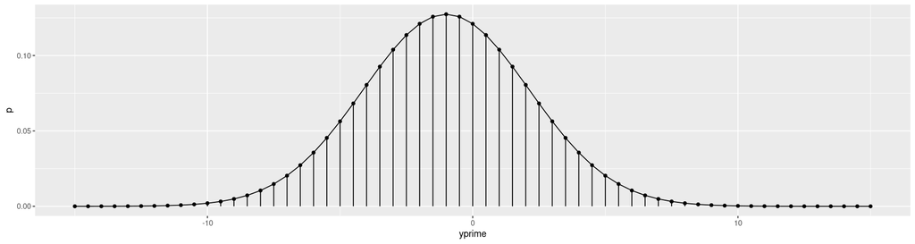

```r
ggplot( post_pred_pdf_eval, aes(x=yprime, y=p) ) +
    geom_point() +
    geom_line() +
    geom_segment( aes(x=yprime, xend=yprime, y=0, yend=p ) )
```

## Exercise 8.14

### b)

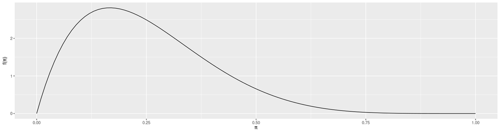

```r
plot_beta( alpha=2, beta=6 )
```

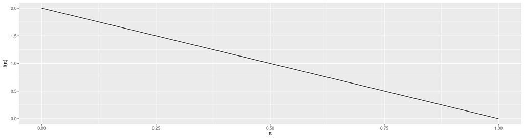

```r
plot_beta( alpha=1, beta=2 )
```

### d)

```r
head( pulse_of_the_nation )
```

A tibble: 6 × 15

| income <dbl> | age <dbl> | party <fct> | trump_approval <fct> | education <fct> | robots <fct> | climate_change <fct> | transformers <dbl> | science_is_honest <fct> | vaccines_are_safe <fct> | books <dbl> | ghosts <fct> | fed_sci_budget <fct> | earth_sun <lgl> | wise_unwise <fct> |
| --- | --- | --- | --- | --- | --- | --- | --- | --- | --- | --- | --- | --- | --- | --- |
| 8 | 64 | Democrat | Strongly disapprove | College degree | Unlikely | Real and Caused by People | 1 | Strongly Agree | Somewhat Disagree | 20 | Yes | Too Low | FALSE | Wise but Unhappy |
| 68 | 56 | Democrat | Strongly disapprove | High school | Unlikely | Real and Caused by People | 0 | Somewhat Agree | Somewhat Disagree | 6 | No | Too High | FALSE | Wise but Unhappy |
| 46 | 63 | Independent | Somewhat Approve | Some college | Unlikely | Real but not Caused by People | 0 | Somewhat Agree | Strongly Agree | 0 | No | About Right | TRUE | Happy but Unwise |
| 51 | 48 | Republican | Strongly Approve | High school | Unlikely | Not Real At All | 0 | Somewhat Disagree | Somewhat Disagree | 1 | No | About Right | FALSE | Happy but Unwise |
| 100 | 32 | Democrat | Somewhat Approve | Some college | Unlikely | Real and Caused by People | 1 | Strongly Agree | Strongly Agree | 30 | Yes | Too Low | FALSE | Wise but Unhappy |
| 54 | 64 | Democrat | Strongly disapprove | Some college | Unlikely | Real and Caused by People | 0 | Strongly Agree | Strongly Agree | 15 | No | Too Low | TRUE | Wise but Unhappy |

```r
table( pulse_of_the_nation$climate_change )
```

```
              Not Real At All     Real and Caused by People
                          150                           655
Real but not Caused by People
                          195
```

```r
pulse_of_the_nation %>%
    group_by( climate_change ) %>%
    summarize( count=n(), prop=n()/dim(pulse_of_the_nation)[1] )
```

A tibble: 3 × 3

| climate_change <fct> | count <int> | prop <dbl> |
| --- | --- | --- |
| Not Real At All | 150 | 0.150 |
| Real and Caused by People | 655 | 0.655 |
| Real but not Caused by People | 195 | 0.195 |

A 15% proportion!

### e)

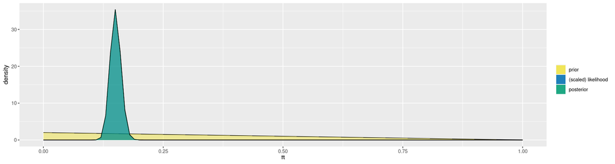

```r
plot_beta_binomial( alpha=1, beta=2, y=150, n=1000 )
```

```r
summarize_beta_binomial( alpha=1, beta=2, y=150, n=1000 )
```

A data.frame: 2 × 7

| model <chr> | alpha <dbl> | beta <dbl> | mean <dbl> | mode <dbl> | var <dbl> | sd <dbl> |
| --- | --- | --- | --- | --- | --- | --- |
| prior | 1 | 2 | 0.3333333 | 0.0000000 | 0.0555555556 | 0.23570226 |
| posterior | 151 | 852 | 0.1505484 | 0.1498501 | 0.0001273741 | 0.01128601 |

Middle 95% posterior credible interval:

```r
0.05/2
```

0.025

```r
qbeta(c(0.025, 0.975), 151, 852)
```

1. 0.129100044905316

2. 0.173316354661389

## Exercise 8.15

### b)

```r
post_pHa <- 1-pbeta(0.1, 151, 852)
post_pHa
```

0.999999687250247

### c)

```r
post_pH0 <- 1-post_pHa
prior_pH0 <- pbeta(0.1, 1, 2)
prior_pHa <- 1-prior_pH0
```

```r
post_odds <- post_pHa / post_pH0
post_odds
```

3197443.56949401

```r
prior_odds <- prior_pHa / prior_pH0
prior_odds
```

4.26315789473686

```r
BF <- post_odds / prior_odds
BF
```

750017.627412173

## Exercise 8.16

### a)

Define the model:

```r
climate_change_model <- "
    data {
        int<lower=0, upper=1000> Y;
    }
    parameters {
        real<lower=0, upper=1> pi;
    }
    model {
        Y ~ binomial(1000, pi);
        pi ~ beta(1, 2);
    }
"
```

Simulate the posterior:

```r
climate_change_sim <- stan(
    model_code = climate_change_model,
    data = list(Y=150),
    chains = 4,
    iter = 10000*2,
    seed = 123
)
```

## b)

#### Trace plots:

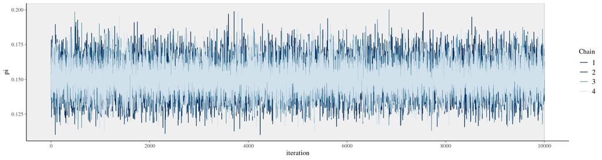

```r
mcmc_trace( climate_change_sim, pars="pi", size=0.5, n_warmup=10000 ) + xlab("iteration")
```

At first sight it looks like all the chains have mixed well!

#### Density overlays:

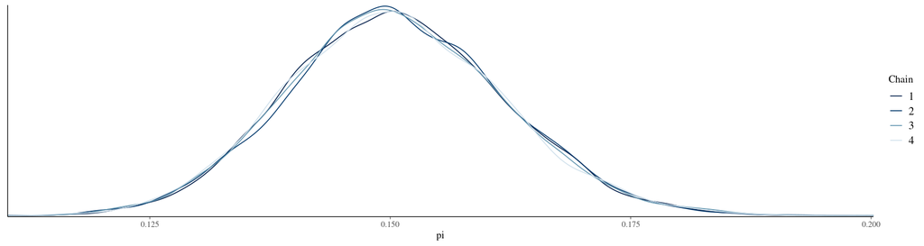

```r
mcmc_dens_overlay( climate_change_sim, pars="pi" )
```

The densities are also quite similar, it seems that all chains have explored the full distribution.

#### Autocorrelation plots:

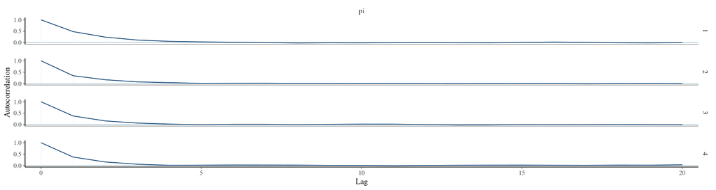

```r
mcmc_acf( climate_change_sim, pars="pi" )
```

Autocorrelation drops to zero after already 5 lags!

### c)

#### Rhat:

```r
rhat( climate_change_sim, pars="pi" )
```

1.00006082403217

Very close to 1 (confirming the conclusion drawn from density overlay).

#### Effective sample size ratio:

```r
neff_ratio( climate_change_sim, pars="pi" )
```

0.407388209797061

Our 40'000 Markov chain values are as effective as $\sim16'000$ uncorrelated samples, this is reasonably efficient.

## Exercise 8.17

### a)

```r
tidy( climate_change_sim, conf.int=TRUE, conf.level=0.95 )
```

A tibble: 1 × 5

| term <chr> | estimate <dbl> | std.error <dbl> | conf.low <dbl> | conf.high <dbl> |
| --- | --- | --- | --- | --- |
| pi | 0.1502483 | 0.01131534 | 0.1291415 | 0.1735051 |

The estimates are extremely close to the computations in Exercise 8.14!

Manual computation of the middle posterior credible interval:

```r
quantile( as.array( climate_change_sim, pars="pi" ), probs=c(0.025, 0.975) )
```

**2.5%**

0.129141470811787

**97.5%**

0.173505131156214

Plot:

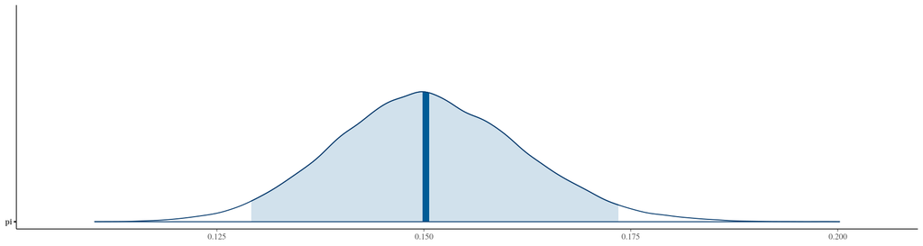

```r
mcmc_areas( climate_change_sim , pars="pi", prob=0.95 )
```

### b)

```r
mean( as.array( climate_change_sim, pars="pi" ) > 0.1 )
```

1

All Markov chain samples for $\pi$ are above 0.1, consistent with the extremely high posterior probability for the alternative hypothesis in exercise 8.15.

### c)

Closeness of credible intervals:

```r
exact_credints <- qbeta(c(0.025, 0.975), 151, 852)
mcmc_credints <- quantile( as.array( climate_change_sim, pars="pi" ), probs=c(0.025, 0.975) )
abs( exact_credints - mcmc_credints ) / exact_credints
```

**2.5%**

0.000320882200326695

**97.5%**

0.00108920185399794

Closeness of posterior probabilities for alternative hypothesis:

```r
1 - post_pHa
```

3.12749753206276e-07

Extremely high precision!

## Exercise 8.18

### a)

```r
climate_change_df <- as.data.frame( climate_change_sim, pars="pi" )
head( climate_change_df )
```

A data.frame: 6 × 1

|  | pi <dbl> |
| --- | --- |
| 1 | 0.1622605 |
| 2 | 0.1606444 |
| 3 | 0.1606444 |
| 4 | 0.1512452 |
| 5 | 0.1673836 |
| 6 | 0.1785230 |

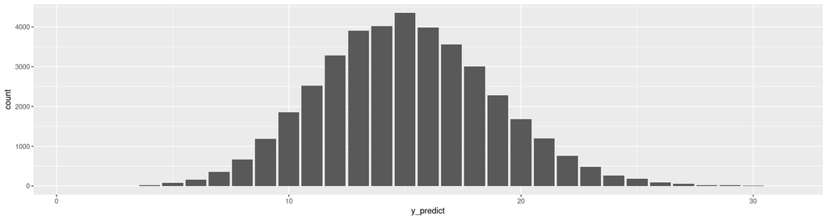

```r
climate_change_pred <- climate_change_df %>%
    mutate( y_predict = rbinom(length(pi), size=100, prob=pi) )

ggplot( climate_change_pred ) + stat_count( aes(x=y_predict) )
```

### b)

```r
climate_change_pred %>% summarise( mean=mean(y_predict), sd=sd(y_predict))
```

A data.frame: 1 × 2

| mean <dbl> | sd <dbl> |
| --- | --- |
| 15.05823 | 3.747064 |

Middle 95%:

```r
quantile( climate_change_pred$y_predict, prob=c(0.025, 0.975) )
```

**2.5%**

8

**97.5%**

23

The mean of the predicted number of people who do not believe in climate change remains approximately the same, however the middle posterior predictive 95% credible interval is significantly enlarged due to sampling variability.

### c)

```r
mean( climate_change_pred$y > 20 )
```

0.076925

8%

## Exercise 8.19

### a)

Test for normality:

```r
adelie <- penguins_bayes %>%
    filter(species=="Adelie") %>%
    filter(!is.na(flipper_length_mm))
```

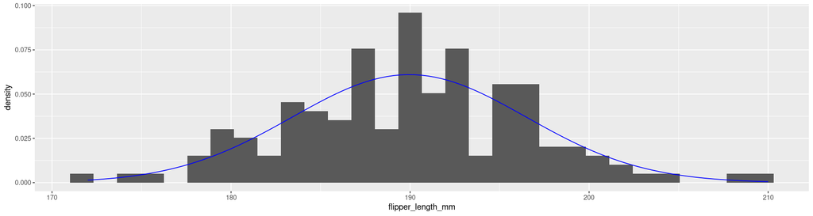

```r
ggplot( adelie, aes(x=flipper_length_mm) ) +
    geom_histogram( aes(y=..density..) ) +
    stat_function(
        fun = dnorm,
        args = list(mean = mean(adelie$flipper_length_mm), sd = sd(adelie$flipper_length_mm)),
        col="blue"
    )
```

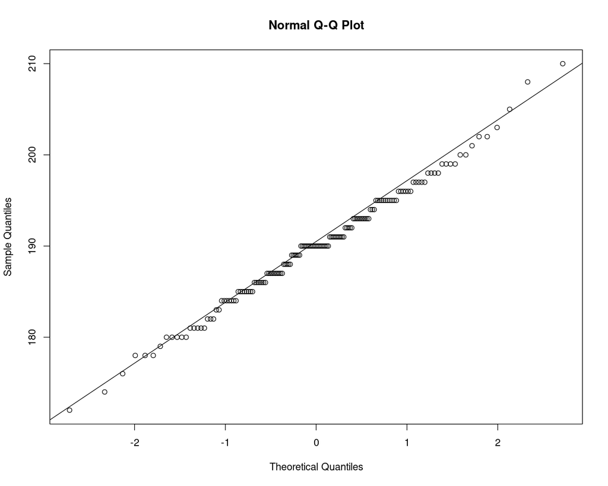

```r
options(repr.plot.width=10, repr.plot.height=8)
qqnorm( adelie$flipper_length_mm )
qqline( adelie$flipper_length_mm )
```

The data seem to fit well to a normal distribution!

### b)

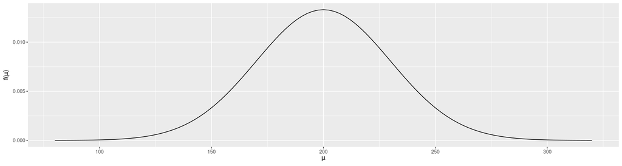

```r
options(repr.plot.width=15, repr.plot.height=4)
plot_normal( mean=200, sd=30 )
```

### c)

```r
dim(adelie)
```

1. 151

2. 9

```r
mean(adelie$flipper_length_mm)
```

189.953642384106

Standard deviation:

```r
sd(adelie$flipper_length_mm)
```

6.5394574171913

### d)

In the previous theoretical exercises, it was usually assumed that $\sigma$ is known. However, in this exercise, no population $\sigma$ is given. This might be a mistake, as normal models with unknown $\sigma$ have not been introduced yet. I have reported this to the authors, for simplicity we just assume that the sample standard deviation is the population standard deviation:

```r
sigma <- sd( adelie$flipper_length_mm )
```

Posterior model:

```r
summarize_normal_normal( mean=200, sd=30, sigma=sigma, y_bar=mean(adelie$flipper_length_mm), n=151 )
```

A data.frame: 2 × 5

| model <chr> | mean <dbl> | mode <dbl> | var <dbl> | sd <dbl> |
| --- | --- | --- | --- | --- |
| prior | 200.0000 | 200.0000 | 900.0000000 | 30.0000000 |
| posterior | 189.9568 | 189.9568 | 0.2831195 | 0.5320898 |

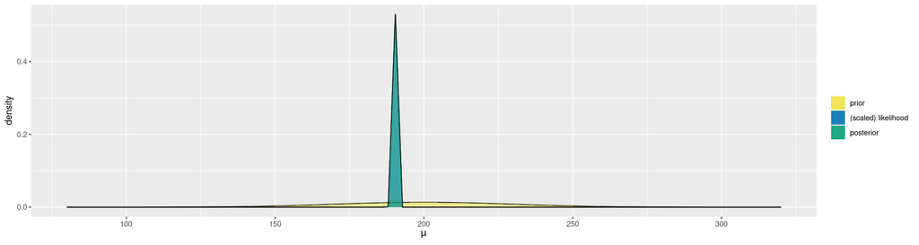

```r
plot_normal_normal( mean=200, sd=30, sigma=sigma, y_bar=mean(adelie$flipper_length_mm), n=151 )
```

95% middle posterior credible interval:

```r
qnorm( c(0.025,0.975), mean=189.957, sd=0.532 )
```

1. 188.914299160225

2. 190.999700839775

## Exercise 8.20

### c)

Posterior probability of the null hypothesis:

```r
pnorm( 220, mean=189.957, sd=0.532 ) - pnorm( 200, mean=189.957, sd=0.532 )
```

0

## Exercise 8.21

### a)

Quick exploratory data analysis of loons dataset:

```r
loons
```

A tibble: 18 × 5

| year <dbl> | count <dbl> | hours <dbl> | count_per_hour <dbl> | count_per_100 <dbl> |
| --- | --- | --- | --- | --- |
| 2000 | 0 | 143.50 | 0.000000000 | 0 |
| 2001 | 7 | 153.50 | 0.045602606 | 5 |
| 2002 | 0 | 228.30 | 0.000000000 | 0 |
| 2003 | 1 | 248.75 | 0.004020101 | 0 |
| 2004 | 1 | 203.75 | 0.004907975 | 0 |
| 2005 | 4 | 245.75 | 0.016276704 | 2 |
| 2006 | 1 | 223.00 | 0.004484305 | 0 |
| 2007 | 4 | 214.00 | 0.018691589 | 2 |
| 2008 | 2 | 227.00 | 0.008810573 | 1 |
| 2009 | 2 | 194.00 | 0.010309278 | 1 |
| 2010 | 0 | 226.25 | 0.000000000 | 0 |
| 2011 | 9 | 227.95 | 0.039482343 | 4 |
| 2012 | 3 | 194.55 | 0.015420200 | 2 |
| 2013 | 0 | 182.20 | 0.000000000 | 0 |
| 2014 | 5 | 179.25 | 0.027894003 | 3 |
| 2015 | 7 | 221.00 | 0.031674208 | 3 |
| 2016 | 2 | 216.65 | 0.009231479 | 1 |
| 2017 | 5 | 198.75 | 0.025157233 | 3 |

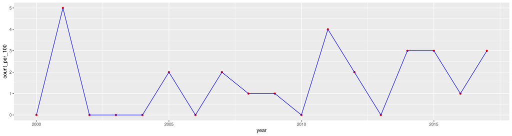

```r
ggplot( loons, aes(x=year, y=count_per_100) ) + geom_point( color="red" ) + geom_line( color="blue" )
```

No visible clear trend over the years.

```r
mean( loons$count_per_100 )
```

1.5

```r
var( loons$count_per_100 )
```

2.5

A poisson distribution should have the same mean and variance $\lambda$! Comparison of relative counts:

```r
props <- loons %>%
    group_by( count_per_100 ) %>%
    summarise( prop=n()/length(loons$count_per_100) )

props$model_prop <- dpois( seq(0,5), lambda = mean(loons$count_per_100) )
props
```

A tibble: 6 × 3

| count_per_100 <dbl> | prop <dbl> | model_prop <dbl> |
| --- | --- | --- |
| 0 | 0.38888889 | 0.22313016 |
| 1 | 0.16666667 | 0.33469524 |
| 2 | 0.16666667 | 0.25102143 |
| 3 | 0.16666667 | 0.12551072 |
| 4 | 0.05555556 | 0.04706652 |
| 5 | 0.05555556 | 0.01411996 |

There is quite some difference! The actual distribution concentrates more mass around a count of zero.

```r
props %>% pivot_longer(-count_per_100)
```

A tibble: 12 × 3

| count_per_100 <dbl> | name <chr> | value <dbl> |
| --- | --- | --- |
| 0 | prop | 0.38888889 |
| 0 | model_prop | 0.22313016 |
| 1 | prop | 0.16666667 |
| 1 | model_prop | 0.33469524 |
| 2 | prop | 0.16666667 |
| 2 | model_prop | 0.25102143 |
| 3 | prop | 0.16666667 |
| 3 | model_prop | 0.12551072 |
| 4 | prop | 0.05555556 |
| 4 | model_prop | 0.04706652 |
| 5 | prop | 0.05555556 |
| 5 | model_prop | 0.01411996 |

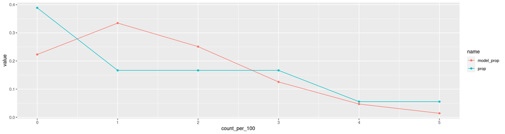

```r
ggplot( props %>% pivot_longer(-count_per_100), aes(x=count_per_100, y=value, col=name) ) +
    geom_point() +
    geom_line()
```

### d)

```r
summarize_gamma_poisson( shape = 4, rate = 2, sum_y = sum(loons$count_per_100), n = 18)
```

A data.frame: 2 × 7

| model <chr> | shape <dbl> | rate <dbl> | mean <dbl> | mode <dbl> | var <dbl> | sd <dbl> |
| --- | --- | --- | --- | --- | --- | --- |
| prior | 4 | 2 | 2.00 | 1.5 | 1.0000 | 1.0000000 |
| posterior | 31 | 20 | 1.55 | 1.5 | 0.0775 | 0.2783882 |

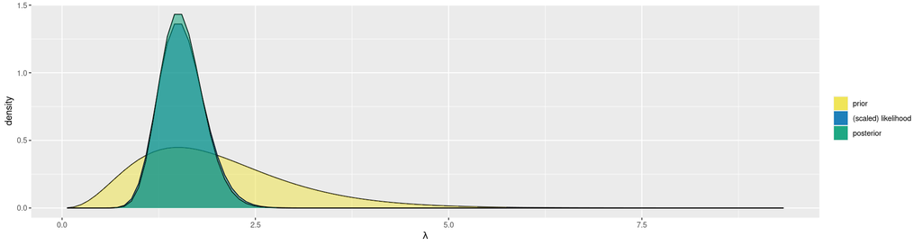

```r
plot_gamma_poisson( shape = 4, rate = 2, sum_y = sum(loons$count_per_100), n = 18)
```

```r
qgamma( c(0.025, 0.975), shape=31, rate=20 )
```

1. 1.05314979895709

2. 2.14134326974038

## Exercise 8.22

### c)

```r
pgamma( 1, shape=31, rate=20 )
```

0.0134746812799223

```r
odds <- (1-pgamma( 1, shape=31, rate=20 )) / pgamma( 1, shape=31, rate=20 )
odds
```

73.2132581265602

## Exercise 8.23

### a)

Define the model:

```r
loons_model <- "
    data {
        int<lower=0> Y[18];
    }
    parameters {
        real<lower=0> lambda;
    }
    model {
        Y ~ poisson(lambda);
        lambda ~ gamma(4, 2);
    }
"
```

Simulate the posterior:

```r
loons_sim <- stan(
    model_code = loons_model,
    data = list(Y = loons$count_per_100),
    chains = 4,
    iter = 10000*2,
    seed = 123
)
```

### b)

#### Trace plots:

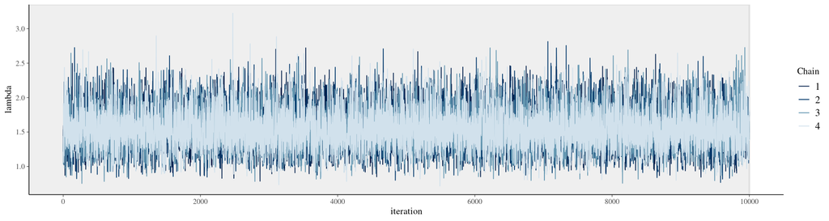

```r
mcmc_trace( loons_sim, pars="lambda", size=0.5, n_warmup=10000 ) + xlab("iteration")
```

At first sight it looks like all the chains have mixed well!

#### Density overlays:

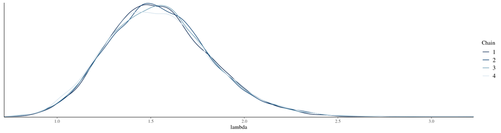

```r
mcmc_dens_overlay( loons_sim, pars="lambda" )
```

The densities are also quite similar, it seems that all chains have explored the full distribution.

#### Autocorrelation plots:

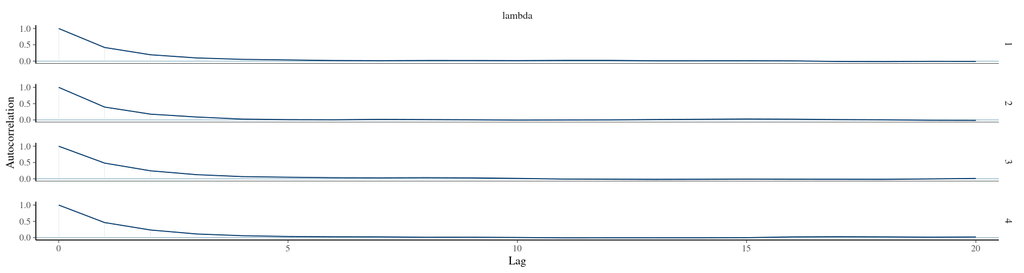

```r
mcmc_acf( loons_sim, pars="lambda" )
```

Autocorrelation drops to zero after already 5 lags!

#### Rhat:

```r
rhat( loons_sim, pars="lambda" )
```

1.00000370856575

Very close to 1 (confirming the conclusion drawn from density overlay).

#### Effective sample size ratio:

```r
neff_ratio( loons_sim, pars="lambda" )
```

0.350108098065328

### c)

```r
tidy( loons_sim, conf.int=TRUE, conf.level=0.95 )
```

A tibble: 1 × 5

| term <chr> | estimate <dbl> | std.error <dbl> | conf.low <dbl> | conf.high <dbl> |
| --- | --- | --- | --- | --- |
| lambda | 1.532534 | 0.2776614 | 1.050233 | 2.146979 |

```r
quantile( as.array( loons_sim, pars="lambda" ), c(0.025,0.975) )
```

**2.5%**

1.05023342861585

**97.5%**

2.14697933214285

### d)

```r
mean( as.array( loons_sim, pars="lambda" ) < 1 )
```

0.012725

Very close to closed form computation.

### e)

middle 95% posterior credible interval:

```r
exact_credints <- qgamma( c(0.025, 0.975), shape=31, rate=20 )
mcmc_credints <- quantile( as.array( loons_sim, pars="lambda" ), c(0.025,0.975) )
abs( exact_credints - mcmc_credints ) / exact_credints
```

**2.5%**

0.00276918852771567

**97.5%**

0.0026320219098503

Difference in the 0.3% regime.

Probability for null hypothesis $H_0$:

```r
abs( mean( as.array( loons_sim, pars="lambda" ) < 1 ) - pgamma( 1, shape=31, rate=20 ) ) / pgamma( 1, shape=31, rate=20 )
```

0.0556362903395208

5.5% difference

### Exercise 8.24

### a)

```r
loons_pred <- as.data.frame( loons_sim, pars="lambda" )
head( loons_pred )
```

A data.frame: 6 × 1

|  | lambda <dbl> |
| --- | --- |
| 1 | 1.443592 |
| 2 | 1.578568 |
| 3 | 1.597217 |
| 4 | 1.407536 |
| 5 | 1.482347 |
| 6 | 1.433530 |

```r
set.seed(1)
loons_pred <- loons_pred %>%
  mutate( y_predict = rpois(length(lambda), lambda = lambda) )

head( loons_pred )
```

A data.frame: 6 × 2

|  | lambda <dbl> | y_predict <int> |
| --- | --- | --- |
| 1 | 1.443592 | 1 |
| 2 | 1.578568 | 1 |
| 3 | 1.597217 | 2 |
| 4 | 1.407536 | 3 |
| 5 | 1.482347 | 0 |
| 6 | 1.433530 | 3 |

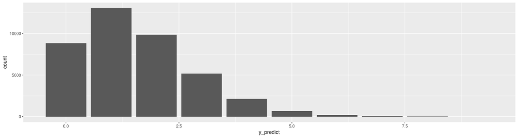

```r
ggplot( loons_pred ) + stat_count( aes(x=y_predict) )
```

### b)

```r
loons_pred %>%
    summarise( mean=mean(y_predict), var=var(y_predict) )
```

A data.frame: 1 × 2

| mean <dbl> | var <dbl> |
| --- | --- |
| 1.54715 | 1.628518 |

```r
table( loons_pred$y_predict )
```

```
    0     1     2     3     4     5     6     7     8     9
 8852 13051  9833  5185  2130   680   205    49    14     1
```

### c)

```r
mean( loons_pred$y_predict == 0 )
```

0.2213